# Sequential_NLP

*PART ONE - SENTIMENT ANALYSIS*

*Import Packages*

```python
#Mounting Google Drive
from google.colab import drive
drive.mount('/content/drive')
```

```python
#Setting the current working directory
import os; os.chdir('drive/My Drive/AIML/NLP')
```

```python
# Import Packages
import pandas as pd, numpy as np
import tensorflow as tf
assert tf.__version__ >= '2.0'

from itertools import islice

# Keras
from keras.layers import Dense, Embedding, LSTM, Dropout, MaxPooling1D, Conv1D
from keras.preprocessing.sequence import pad_sequences
from keras.models import Model, Sequential
from keras.preprocessing import sequence
from keras.datasets import imdb

from keras.callbacks import ModelCheckpoint, EarlyStopping

from sklearn.model_selection import train_test_split
from sklearn.metrics import classification_report

# Suppress warnings
import warnings; warnings.filterwarnings('ignore')

random_state = 42
np.random.seed(random_state)
tf.random.set_seed(random_state)
```

*1. Import and analyse the data set.*

```python
#Loading Dataset - Train & Test Split
vocab_size = 10000
maxlen = 300
(x_train, y_train), (x_test, y_test) = imdb.load_data(num_words = vocab_size)
print("shape of the training data set:", x_train.shape ,y_train.shape)
print("shape of the test data set:", x_test.shape ,y_test.shape)
```

```
shape of the training data set: (25000,) (25000,)
shape of the test data set: (25000,) (25000,)
```

*2. Perform relevant sequence adding on the data*

```python
x_train = pad_sequences(x_train, maxlen = maxlen, padding = 'pre')
x_test =  pad_sequences(x_test, maxlen = maxlen, padding = 'pre')
```

*3. Perform following data analysis:*

*3.Print shape of features and label*

```python
X = np.concatenate((x_train, x_test), axis = 0)
y = np.concatenate((y_train, y_test), axis = 0)

print ("Shape of the features ", X.shape)
print ("Shape of the label ", y.shape)
```

```
Shape of the features  (50000, 300)
Shape of the label  (50000,)
```

```python
print('---'*20, f'\nUnique Categories: {np.unique(y)}')
print("Number of unique words:", len(np.unique(np.hstack(X))))

length = [len(i) for i in X]
print("Average Review length:", np.mean(length))
print("Standard Deviation:", round(np.std(length)))
```

```
------------------------------------------------------------
Unique Categories: [0 1]
Number of unique words: 9999
Average Review length: 300.0
Standard Deviation: 0
```

*Print value of any one feature and it's label*

```python
print("Label:", y[1])
print(" feature :",X[1])
```

```
Label: 0
 feature : [   0    0    0    0    0    0    0    0    0    0    0    0    0    0
    0    0    0    0    0    0    0    0    0    0    0    0    0    0
    0    0    0    0    0    0    0    0    0    0    0    0    0    0
    0    0    0    0    0    0    0    0    0    0    0    0    0    0
    0    0    0    0    0    0    0    0    0    0    0    0    0    0
    0    0    0    0    0    0    0    0    0    0    0    0    0    0
    0    0    0    0    0    0    0    0    0    0    0    0    0    0
    0    0    0    0    0    0    0    0    0    0    0    0    0    1
  194 1153  194 8255   78  228    5    6 1463 4369 5012  134   26    4
  715    8  118 1634   14  394   20   13  119  954  189  102    5  207
  110 3103   21   14   69  188    8   30   23    7    4  249  126   93
    4  114    9 2300 1523    5  647    4  116    9   35 8163    4  229
    9  340 1322    4  118    9    4  130 4901   19    4 1002    5   89
   29  952   46   37    4  455    9   45   43   38 1543 1905  398    4
 1649   26 6853    5  163   11 3215    2    4 1153    9  194  775    7
 8255    2  349 2637  148  605    2 8003   15  123  125   68    2 6853
   15  349  165 4362   98    5    4  228    9   43    2 1157   15  299
  120    5  120  174   11  220  175  136   50    9 4373  228 8255    5
    2  656  245 2350    5    4 9837  131  152  491   18    2   32 7464
 1212   14    9    6  371   78   22  625   64 1382    9    8  168  145
   23    4 1690   15   16    4 1355    5   28    6   52  154  462   33
   89   78  285   16  145   95]
```

```python
x_train, x_test, y_train, y_test = train_test_split(X, y, test_size = 0.2, random_state = random_state, shuffle = True)
x_train, x_valid, y_train, y_valid = train_test_split(x_train, y_train, test_size = 0.2, random_state = random_state, shuffle = True)

print('---'*20, f'\nNumber of rows in training dataset: {x_train.shape[0]}')
print(f'Number of columns in training dataset: {x_train.shape[1]}')
print(f'Number of unique words in training dataset: {len(np.unique(np.hstack(x_train)))}')


print('---'*20, f'\nNumber of rows in validation dataset: {x_valid.shape[0]}')
print(f'Number of columns in validation dataset: {x_valid.shape[1]}')
print(f'Number of unique words in validation dataset: {len(np.unique(np.hstack(x_valid)))}')


print('---'*20, f'\nNumber of rows in test dataset: {x_test.shape[0]}')
print(f'Number of columns in test dataset: {x_test.shape[1]}')
print(f'Number of unique words in test dataset: {len(np.unique(np.hstack(x_test)))}')


print('---'*20, f'\nUnique Categories: {np.unique(y_train), np.unique(y_valid), np.unique(y_test)}')
```

```
------------------------------------------------------------
Number of rows in training dataset: 32000
Number of columns in training dataset: 300
Number of unique words in training dataset: 9999
------------------------------------------------------------
Number of rows in validation dataset: 8000
Number of columns in validation dataset: 300
Number of unique words in validation dataset: 9984
------------------------------------------------------------
Number of rows in test dataset: 10000
Number of columns in test dataset: 300
Number of unique words in test dataset: 9995
------------------------------------------------------------
Unique Categories: (array([0, 1]), array([0, 1]), array([0, 1]))
```

*4. Decode the feature value to get original sentence*

```python
#Get word index and create a key-value pair for word and word id
def decode_review(x, y):
  w2i = imdb.get_word_index()
  w2i = {k:(v + 3) for k, v in w2i.items()}
  w2i['<PAD>'] = 0
  w2i['<START>'] = 1
  w2i['<UNK>'] = 2
  i2w = {i: w for w, i in w2i.items()}

  ws = (' '.join(i2w[i] for i in x))
  print(f'Review: {ws}')
  print(f'Actual Sentiment: {y}')
  return w2i, i2w

w2i, i2w = decode_review(x_train[0], y_train[0])

# get first 50 key, value pairs from id to word dictionary
print('---'*30, '\n', list(islice(i2w.items(), 0, 50)))
```

```
Review: <PAD> <PAD> <PAD> <PAD> <PAD> <PAD> <PAD> <PAD> <PAD> <PAD> <PAD> <PAD> <PAD> <PAD> <PAD> <PAD> <PAD> <PAD> <PAD> <PAD> <PAD> <PAD> <PAD> <PAD> <PAD> <PAD> <PAD> <PAD> <PAD> <PAD> <PAD> <PAD> <PAD> <PAD> <PAD> <PAD> <PAD> <PAD> <PAD> <PAD> <PAD> <PAD> <PAD> <PAD> <PAD> <PAD> <PAD> <PAD> <PAD…
Actual Sentiment: 0
------------------------------------------------------------------------------------------
 [(34704, 'fawn'), (52009, 'tsukino'), (52010, 'nunnery'), (16819, 'sonja'), (63954, 'vani'), (1411, 'woods'), (16118, 'spiders'), (2348, 'hanging'), (2292, 'woody'), (52011, 'trawling'), (52012, "hold's"), (11310, 'comically'), (40833, 'localized'), (30571, 'disobeying'), (52013, "'royale"), (40834…
```

*5. Design, train, tune and test a sequential model.*

```python
# Model
model = Sequential()
model.add(Embedding(vocab_size, 256, input_length = maxlen))
model.add(Dropout(0.25))
model.add(Conv1D(256, 5, padding = 'same', activation = 'relu', strides = 1))
model.add(Conv1D(128, 5, padding = 'same', activation = 'relu', strides = 1))
model.add(MaxPooling1D(pool_size = 2))
model.add(Conv1D(64, 5, padding = 'same', activation = 'relu', strides = 1))
model.add(MaxPooling1D(pool_size = 2))
model.add(LSTM(75))
model.add(Dense(1, activation = 'sigmoid'))
model.compile(loss = 'binary_crossentropy', optimizer = 'adam', metrics = ['accuracy'])
print(model.summary())

# Adding callbacks
es = EarlyStopping(monitor = 'val_loss', mode = 'min', verbose = 1, patience = 0)
mc = ModelCheckpoint('imdb_model.h5', monitor = 'val_loss', mode = 'min', save_best_only = True, verbose = 1)
```

```
Model: "sequential"
_________________________________________________________________
Layer (type)                 Output Shape              Param #
=================================================================
embedding (Embedding)        (None, 300, 256)          2560000
_________________________________________________________________
dropout (Dropout)            (None, 300, 256)          0
_________________________________________________________________
conv1d (Conv1D)              (None, 300, 256)          327936
_________________________________________________________________
conv1d_1 (Conv1D)            (None, 300, 128)          163968
_________________________________________________________________
max_pooling1d (MaxPooling1D) (None, 150, 128)          0
_________________________________________________________________
conv1d_2 (Conv1D)            (None, 150, 64)           41024
_________________________________________________________________
max_pooling1d_1 (MaxPooling1 (None, 75, 64)            0
_________________________________________________________________
lstm (LSTM)                  (None, 75)                42000
_________________________________________________________________
dense (Dense)                (None, 1)                 76
=================================================================
Total params: 3,135,004
Trainable params: 3,135,004
Non-trainable params: 0
_________________________________________________________________
None
```

```python
# Fit the model
model.fit(x_train, y_train, validation_data = (x_valid, y_valid), epochs = 3, batch_size = 64, verbose = True, callbacks = [es, mc])

# Evaluate the model
scores = model.evaluate(x_test, y_test, batch_size = 64)
print('Test accuracy: %.2f%%' % (scores[1]*100))
```

```
Epoch 00001: val_loss improved from inf to 0.24996, saving model to imdb_model.h5

Epoch 00002: val_loss did not improve from 0.24996
Epoch 00002: early stopping
Test accuracy: 89.51%
```

```python
y_pred = model.predict_classes(x_test)
print(f'Classification Report:\n{classification_report(y_pred, y_test)}')
```

[output not shown]

*6. Use the designed model to print the prediction on any one sample.*

```python
sample_x_test = x_test[np.random.randint(10000)]
for layer in model.layers:

    model_layer = Model(inputs = model.input, outputs = model.get_layer(layer.name).output)
    output = model_layer.predict(sample_x_test.reshape(1,-1))
    print('\n','--'*20, layer.name, 'layer', '--'*20, '\n')
    print(output)
```

[output not shown]

[output cut: 52 more lines]

[output not shown]

```python
decode_review(x_test[10], y_test[10])
print(f'Predicted sentiment: {y_pred[10][0]}')
```

```
Review: <PAD> <PAD> <PAD> <PAD> <PAD> <PAD> <PAD> <PAD> <PAD> <PAD> <PAD> <PAD> <PAD> <PAD> <PAD> <PAD> <PAD> <PAD> <PAD> <PAD> <PAD> <PAD> <PAD> <PAD> <PAD> <PAD> <PAD> <PAD> <PAD> <PAD> <PAD> <PAD> <PAD> <PAD> <PAD> <PAD> <PAD> <PAD> <PAD> <PAD> <PAD> <PAD> <PAD> <PAD> <PAD> <PAD> <PAD> <PAD> <PAD…
Actual Sentiment: 1
Predicted sentiment: 1
```

*Conclusion:*

Sequential NLP classifier has been built to detect customer Sentiments on the IMDB test dataset. Accuracy: 90% F1-score: 90% Loss of 0.25

*PART TWO - Sarcasm Detection*

```python
# Import packages
import warnings; warnings.filterwarnings('ignore')
import pandas as pd, numpy as np, tensorflow as tf
import matplotlib.pyplot as plt, seaborn as sns
import matplotlib.style as style

import random, re
assert tf.__version__ >= '2.0'
%matplotlib inline

# Text preprocessing and stopwords
from keras.preprocessing import * #(custom module)

# Models
from tensorflow.keras.layers import Dense, LSTM, Embedding, Dropout, Flatten, Bidirectional, GlobalMaxPool1D
from tensorflow.keras.callbacks import EarlyStopping, ModelCheckpoint, ReduceLROnPlateau, TensorBoard
from tensorflow.keras.preprocessing.sequence import pad_sequences
from tensorflow.keras.preprocessing.text import Tokenizer
from tensorflow.keras.models import Model, Sequential
from tensorflow.keras.initializers import Constant

from sklearn.metrics import classification_report, confusion_matrix
from sklearn.model_selection import train_test_split

# Set random state
random_state = 42
np.random.seed(random_state)
tf.random.set_seed(random_state)

import nltk
from nltk.corpus import stopwords
from collections import Counter
from wordcloud import WordCloud

import warnings
warnings.filterwarnings('ignore')
```

*1. Read and explore the data*

```python
#Loading Dataset
data = pd.read_json('./Sarcasm_Headlines_Dataset.json', lines = True)
print(f'Data has {data.shape[0]} rows and {data.shape[1]} columns. Here are the first five rows of the data...')
display(data.head())
```

```
Data has 26709 rows and 3 columns. Here are the first five rows of the data...
```

|  | article_link | headline | is_sarcastic |
| --- | --- | --- | --- |
| 0 | https://www.huffingtonpost.com/entry/versace-b... | former versace store clerk sues over secret 'b... | 0 |
| 1 | https://www.huffingtonpost.com/entry/roseanne-... | the 'roseanne' revival catches up to our thorn... | 0 |
| 2 | https://local.theonion.com/mom-starting-to-fea... | mom starting to fear son's web series closest ... | 1 |
| 3 | https://politics.theonion.com/boehner-just-wan... | boehner just wants wife to listen, not come up... | 1 |
| 4 | https://www.huffingtonpost.com/entry/jk-rowlin... | j.k. rowling wishes snape happy birthday in th... | 0 |

```
------------------------------------------------------------
Value Counts for `is_sarcastic` label
------------------------------------------------------------
Is Sarcastic count: 11724 i.e. 44.0%
Isn't Sarcastic count: 14985 i.e. 56.0%
------------------------------------------------------------
Distributon of `is_sarcastic` label
------------------------------------------------------------
```

[figure not shown]

```python
print('--'*30); print('Value Counts for `is_sarcastic` label'); print('--'*30)
print(f'Is Sarcastic count: {data[data.is_sarcastic == 1].shape[0]} i.e. {round(data[data.is_sarcastic == 1].shape[0]/data.shape[0]*100, 0)}%')
print(f'Isn\'t Sarcastic count: {data[data.is_sarcastic == 0].shape[0]} i.e. {round(data[data.is_sarcastic == 0].shape[0]/data.shape[0]*100, 0)}%')
print('--'*30); print('Distributon of `is_sarcastic` label'); print('--'*30)
_ = data['is_sarcastic'].value_counts().plot(kind = 'pie', autopct = '%.0f%%', labels = ['Sarcastic', 'Non-sarcastic'], figsize = (10, 15))
```

*2. Retain relevant columns*

```python
print('Analysis of `is_sarcastic` label by news website'); print('--'*30)

hf = data[data['article_link'].str.contains('huffingtonpost.com')].shape[0]
op = data[data['article_link'].str.contains('theonion.com')].shape[0]

is_sarcastic_hf = data.loc[(data['article_link'].str.contains('huffingtonpost.com')) & (data['is_sarcastic'] == 1)].shape[0]
not_sarcastic_hf = data.loc[(data['article_link'].str.contains('huffingtonpost.com')) & (data['is_sarcastic'] == 0)].shape[0]

is_sarcastic_op = data.loc[(data['article_link'].str.contains('theonion.com')) & (data['is_sarcastic'] == 1)].shape[0]
not_sarcastic_op = data.loc[(data['article_link'].str.contains('theonion.com')) & (data['is_sarcastic'] == 0)].shape[0]

display(pd.DataFrame([[is_sarcastic_hf, is_sarcastic_op], [not_sarcastic_hf, not_sarcastic_op]],
                     columns = ['huffingtonpost', 'theonion'], index = ['Sarcastic', 'Non-sarcastic']))
```

```
Analysis of `is_sarcastic` label by news website
------------------------------------------------------------
```

|  | huffingtonpost | theonion |
| --- | --- | --- |
| Sarcastic | 0 | 11724 |
| Non-sarcastic | 14985 | 1 |

```python
# Checking 5 random headlines and labels from the data
print('--'*30); print('Checking 5 random headlines and labels from the data'); print('--'*30)
rands = random.sample(range(1, data.shape[0]), 5)
headlines, labels = list(data.loc[rands, 'headline']), list(data.loc[rands, 'is_sarcastic'])

_ = [print(f'Headline: {head}\nlabel: {label}\n') for head, label in zip(headlines, labels)]
```

```
------------------------------------------------------------
Checking 5 random headlines and labels from the data
------------------------------------------------------------
Headline: deconstructing stigma: helping yourself and others
label: 0

Headline: revisit your favorite junkie pals in the 'trainspotting 2' trailer
label: 0

Headline: new film only stars one eddie  murphy
label: 1

Headline: tank rolls by living room window
label: 1

Headline: secretive whcd pre-party draws hollywood celebrities
label: 0
```

```
------------------------------------------------------------
Checking 5 random headlines and labels from the data where the length of headline is > 100
------------------------------------------------------------
Headline: parents officially designate upstairs television for anyone who doesn't want to watch thanksgiving football
label: 1

Headline: newborn prince of cambridge begins consolidating power by having family imprisoned in tower of london
label: 1

Headline: quantum political scientists hypothesize country headed in both right and wrong directions simultaneously
label: 1

Headline: online activists unsure about offensiveness of article, figure they'll destroy author's life just in case
label: 1

Headline: director of census bureau calls for updated population report after realizing he forgot to count himself
label: 1

------------------------------------------------------------
Distributon of label where the length of headline is > 100
------------------------------------------------------------
```

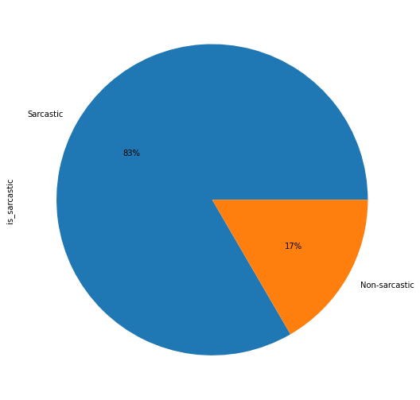

```python
# Checking 5 random headlines and labels from the data where the length of headline is > 100
print('--'*30); print('Checking 5 random headlines and labels from the data where the length of headline is > 100'); print('--'*30)
indexes = list(data.loc[data['headline'].str.len() > 100, 'headline'].index)
rands = random.sample(indexes, 5)
headlines, labels = list(data.loc[rands, 'headline']), list(data.loc[rands, 'is_sarcastic'])

_ = [print(f'Headline: {head}\nlabel: {label}\n') for head, label in zip(headlines, labels)]

print('--'*30); print('Distributon of label where the length of headline is > 100'); print('--'*30)
_ = data.loc[indexes, 'is_sarcastic'].value_counts().plot(kind = 'pie', autopct = '%.0f%%', labels = ['Sarcastic', 'Non-sarcastic'], figsize = (10, 9))
```

```python
print('Dropping `article_link` from the data'); print('--'*30)
data.drop('article_link', axis = 1, inplace = True)
```

```
Dropping `article_link` from the data
------------------------------------------------------------
```

44% of the data have sarcastic labels but 56% don't.